# Assigment 1 - Reproducible Research - Coursera

aplage

December 20, 2015

## Required packages

For this assigment the following needed packages were loaded: *dplyr* and *lattice*

```r
require(dplyr)
require(lattice)
```

## Getting files

Data files are in the Github repository for the assingment (“http://github.com/rdpeng/RepData_PeerAssessment1”), that was forked to my repository.

Set the working directory to the cloned repository directory in your computer.

## Getting Data

The *activity.zip* file from the Github repository for the assingment was unzipped.

```r
unzip("activity.zip")
```

Then, the data was read from the *activity.csv* file into *activity* data frame.

```r
activity <- read.table("activity.csv",
                       header = TRUE,
                       sep = ",",
                       dec = ".",
                       na.strings = "NA",
                       colClasses = c("numeric", "Date", "numeric"),
                       stringsAsFactors = FALSE)
```

## What is mean total number of steps taken per day?

### Histogram

To make the histogram of the total number of steps taken each day, data was grouped by date and the total number of steps taken each day was calculated.

```r
activity %>%
     group_by(date) %>%
          summarize(sum(steps)) -> TotalStepsPerDay
names(TotalStepsPerDay) <-c("date", "sumSteps")
```

Then, the histogram was plotted.

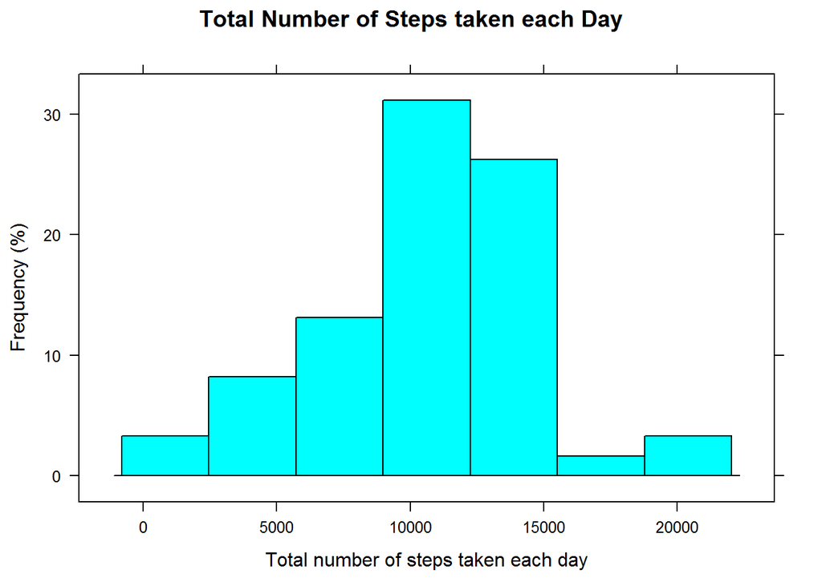

```r
histogram(~TotalStepsPerDay$sumSteps,
          main =  "Total Number of Steps taken each Day",
          xlab = "Total number of steps taken each day",
          ylab = "Frequency (%)")
```

### Calculating and reporting the mean and median total number of steps taken per day

```r
mean(TotalStepsPerDay[[2]], na.rm  = TRUE) -> m
median(TotalStepsPerDay[[2]], na.rm  = TRUE) -> md
```

The mean number of steps per day was **10766.19** and the median was **10765**.

## What is the average daily activity pattern?

To make a time series plot of the 5-minute interval and the average number of steps taken, averaged across all days, data was grouped by interval and the mean was calculated. The missing values in the dataset were ignored.

```r
activity %>%
     group_by(interval) %>%
     summarise(mean(steps, na.rm = TRUE)
     ) -> meanStepsBYinterval
names(meanStepsBYinterval) <- c("interval","meanStepsBYinterval")
```

Then, the data were plotted.

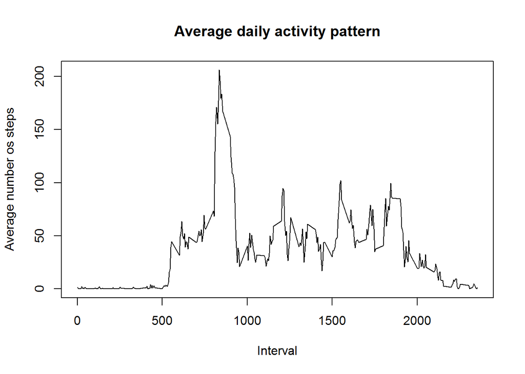

```r
plot(levels(as.factor(activity$interval)),
     meanStepsBYinterval$meanStepsBYinterval,
     main = "Average daily activity pattern",
     type = "l",
     xlab = "Interval",
     ylab = "Average number os steps"
     )
```

### Which 5-minute interval, on average across all the days in the dataset, contains the maximum number of steps?

```r
max(meanStepsBYinterval[,2]) -> maxI
meanStepsBYinterval[[which(meanStepsBYinterval[,2] == maxI),1]] -> intervalmaxI
```

The maximum number os steps in a 5-minute interval was **206.17** and it was at interval **835**.

## Imputing missing values

### Calculating and reporting the total number of missing values in the dataset.

Checking which variables contain missing values.

```r
sapply(activity, anyNA)
```

```
##    steps     date interval
##     TRUE    FALSE    FALSE
```

Calculating the total number of missing values in the dataset:

```r
sum(is.na(activity$steps)) -> sumNA
```

The total number of missing values in the dataset was **2304**.

### Devising a strategy for filling in all of the missing values in the dataset.

For filling in the missing value, the mean for that 5-minute interval was used.

### Creating a new dataset that is equal to the original dataset but with the missing data filled in

The code for the creating the new dataset, newActivity, was:

```r
newActivity <- left_join(activity, meanStepsBYinterval, by = "interval")

newActivity %>%
     mutate(newsteps = ifelse(is.na(steps), meanStepsBYinterval, steps)) -> newActivity
```

Then, the variable meanStepsBYinterval, that is no more needed, was removed.

```r
newActivity$meanStepsBYinterval <- NULL
```

### Making a histogram of the total number of steps taken each day using the dataset with the missing values filled in, newActivity

To make a histogram of the total number of steps taken each day, data in newActivity dataset was grouped by date and the total number of steps per day was calculated.

```r
newActivity %>%
     group_by(date) %>%
     summarize(sum(newsteps)) -> newTotalStepsPerDay
names(newTotalStepsPerDay) <-c("date", "newsumSteps")
```

Then, the histogram was plotted.

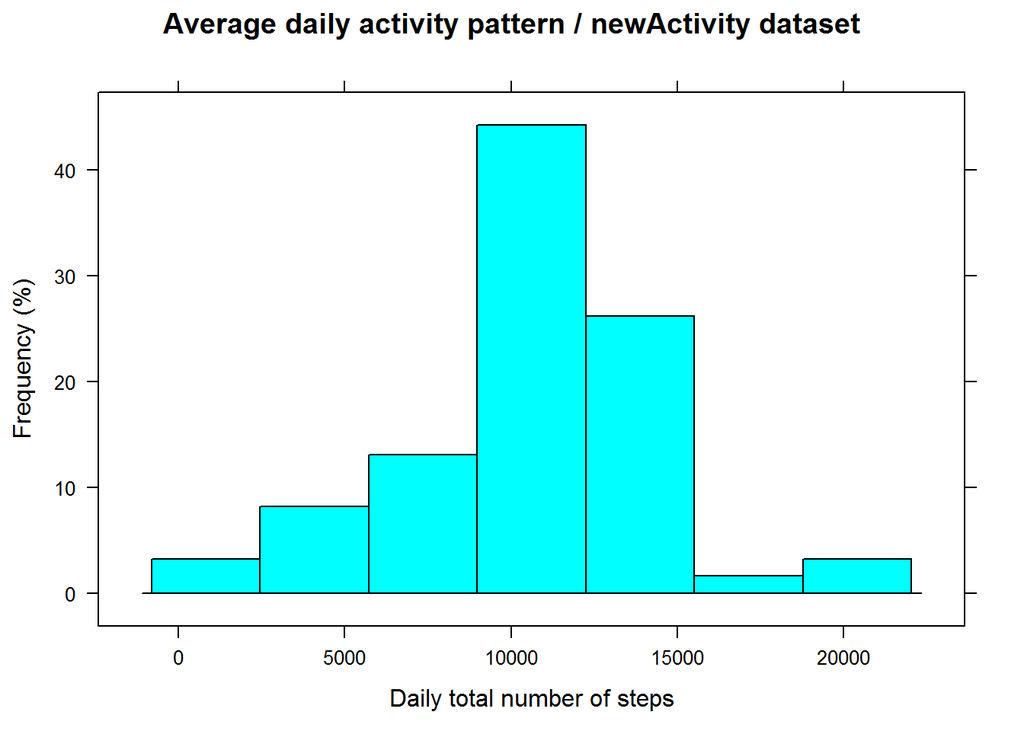

```r
histogram(~newsumSteps,
          data = newTotalStepsPerDay,
          main = "Average daily activity pattern / newActivity dataset",
          xlab = "Daily total number of steps",
          ylab = "Frequency (%)"
          )
```

### Calculating and reporting the mean and median total number of steps taken per day

```r
mean(newTotalStepsPerDay[[2]], na.rm  = TRUE) -> mnoNA
median(newTotalStepsPerDay[[2]], na.rm  = TRUE) -> mdnoNA
```

The mean number of steps per day in the new dataset, newActivity, was **10766.19** and the median was **10766.19**.

### Do these values differ from the estimates from the first part of the assignment? What is the impact of imputing missing data on the estimates of the total daily number of steps?

The following table compares the calculted mean and median using the dataset with missing values, *activity*, and the one with the missing values replaced by the mean of that interval, *newActivity*.

```r
knitr::kable(
matrix(data = c(m,mnoNA,md, mdnoNA),
       nrow = 2,
       byrow = FALSE,
       dimnames = list(Dataset = c("activity", "newActivity"), Statistics = c("Mean", "Median"))
       )
)
```

|  | Mean | Median |
| --- | --- | --- |
| activity | 10766.19 | 10765.00 |
| newActivity | 10766.19 | 10766.19 |

As it was decided to use the mean for the interval in the new dataset, newActivity, no difference was observed in the mean value of daily number of steps, but a change in the median was observed, with an increase in the median value towards the mean value.